# DV_FinalProject

Monica and Rachel

December 6, 2015

## **Introduction**

Many go through the education system without noticing the trends and patterns that appear throughout different schools. The programs a school offers its students as well as teachers and peers can influence a student’s academic development. In our presentation, we discuss just some of the patterns that we noticed while doing out project. To demonstrate our findings, we will be using R Studio, SQL, Tableau, and Shiny.

## **Step 1: Loading Data into Oracle Database**

For our project, we included four different datasets.

Our first dataset displays the different schools and their varying Math, Reading, and Writing grades as well as their growth rates. It also includes both initial and final plantypes that schools adopt while educating their students in A schools, elementaries, middle schools, and high schools. We used the code below to extract, transform, and load the data into an sql statement:

```r
source("../01 Data/ETL.R")
```

```
## 'data.frame':    2069 obs. of  26 variables:
##  $ SCHOOLNAME                   : chr  "BEAR CREEK ELEMENTARY SCHOOL" "CHERRY HILLS VILLAGE ELEMENTARY SCHOOL" "CHEYENNE MOUNTAIN ELEMENTARY SCHOOL" "CHINOOK TRAIL ELEMENTARY SCHOOL" ...
##  $ DISTrictNUMBER               : int  480 130 1020 1040 1040 880 130 880 1560 1420 ...
##  $ DISTRICTNAME                 : chr  "BOULDER VALLEY RE 2" "CHERRY CREEK 5" "CHEYENNE MOUNTAIN 12" "ACADEMY 20" ...
##  $ EMH                          : chr  "E" "E" "E" "E" ...
##  $ EMH_Combined                 : chr  "" "" "" "" ...
##  $ SCHOOLNUMBER                 : int  652 1574 1586 1615 1630 1908 1916 2027 2089 5758 ...
##  $ AEC_10                       : int  0 0 0 0 0 0 0 0 0 0 ...
##  $ Charter                      : int  0 0 0 0 1 0 0 0 0 0 ...
##  $ Online                       : int  0 0 0 0 0 0 0 0 0 0 ...
##  $ INITIAL_PlanType             : chr  "Performance Plan" "Performance Plan" "Performance Plan" "Performance Plan" ...
##  $ FINAL_PlanType               : chr  "Performance Plan" "Performance Plan" "Performance Plan" "Performance Plan" ...
##  $ Notes                        : chr  "" "" "" "" ...
##  $ EMH_2lvl                     : int  1 1 1 1 2 1 1 1 1 1 ...
##  $ LT100pnts                    : int  0 0 0 0 0 0 0 0 0 0 ...
##  $ School_Grade                 : int  13 13 13 13 13 13 13 13 13 13 ...
##  $ rank_tot                     : int  1 1 1 1 1 1 1 1 1 1 ...
##  $ Overall_ACH_Grade            : int  13 12 13 12 13 12 12 13 12 12 ...
##  $ Read_Ach_Grade               : int  12 12 12 12 13 12 12 13 12 12 ...
##  $ Math_Ach_Grade               : int  13 12 12 12 12 13 13 13 13 12 ...
##  $ Write_Ach_Grade              : int  12 13 13 12 12 12 12 13 11 10 ...
##  $ Sci_Ach_Grade                : int  12 12 12 11 13 12 12 13 12 11 ...
##  $ Overall_Weighted_Growth_Grade: int  13 13 12 13 10 12 13 12 13 13 ...
##  $ Read_Growth_Grade            : int  12 13 9 12 9 13 13 12 13 12 ...
##  $ Math_Growth_Grade            : int  12 12 10 13 9 10 12 10 13 12 ...
##  $ Write_Growth_Grade           : int  12 13 12 9 10 11 12 10 13 12 ...
##  $ SPF_PS_IND_GRAD_RATE         : chr  "" "" "" "" ...
## CREATE TABLE 2011_final_grade (
## -- Change table_name to the table name you want.
##  SCHOOLNAME varchar2(4000),
##  DISTRICTNAME varchar2(4000),
##  EMH varchar2(4000),
##  EMH_Combined varchar2(4000),
##  INITIAL_PlanType varchar2(4000),
##  FINAL_PlanType varchar2(4000),
##  Notes varchar2(4000),
##  DISTrictNUMBER number(38,4),
##  SCHOOLNUMBER number(38,4),
##  AEC_10 number(38,4),
##  Charter number(38,4),
##  Online number(38,4),
##  EMH_2lvl number(38,4),
##  LT100pnts number(38,4),
##  School_Grade number(38,4),
##  rank_tot number(38,4),
##  Overall_ACH_Grade number(38,4),
##  Read_Ach_Grade number(38,4),
##  Math_Ach_Grade number(38,4),
##  Write_Ach_Grade number(38,4),
##  Sci_Ach_Grade number(38,4),
##  Overall_Weighted_Growth_Grade number(38,4),
##  Read_Growth_Grade number(38,4),
##  Math_Growth_Grade number(38,4),
##  Write_Growth_Grade number(38,4),
##  SPF_PS_IND_GRAD_RATE number(38,4)
##  );
```

Our second dataset focused on the free and reduced lunches that the schools had to offer. The code we used was:

```r
source("../01 Data/ETL_2.R")
```

Our third dataset depicted the distribution of ethnic employees working at the schools. Our code is listed below:

```r
source("../01 Data/ETL_3.R")
```

Lastly, our final dataset gives a clear depiction of the attendance and truancy rates at schools. We used the code below:

```r
source("../01 Data/ETL_4.R")
```

## **Visualizations**

To create our visualizations, we started out creating them in Tableau and playing around with different options to find a meaningful visualization. Then, we attempted to replicated them in R Studio, SQL, and Shiny.

### **Tableau**

#### **Histogram: The effects of big school size on overall achievement**

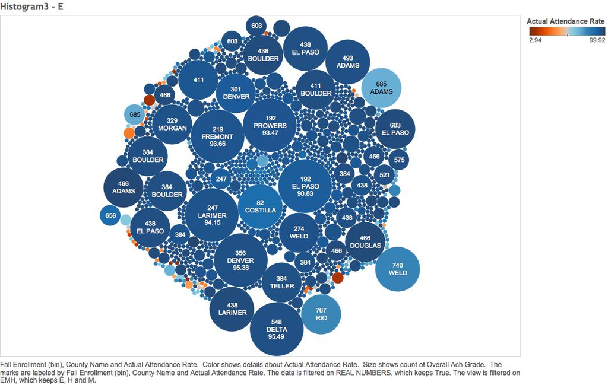

#### **Scatter Plot: The effects of free and reduced lunches on attendance**

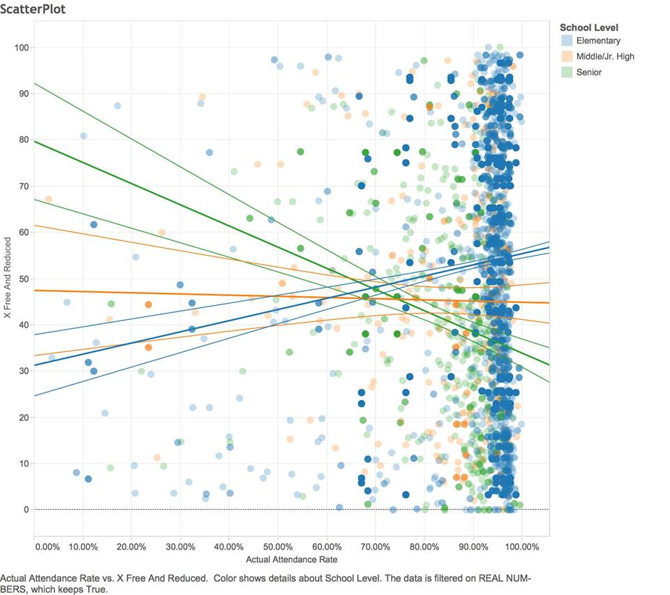

Our scatter plot shows the relationship between the rate of free and reduced lunches and attendance rates among elementary, middle school, and high school. From our plot, we noticed that the majority of the elementary schools and even the middle/jr. high schools seemed to congregate around 90-100% attendance rate, while the senior high schools seemed to be more widespread and lacked a consistent attendence rate.

#### **Crosstab: The effects of attendance on learning**

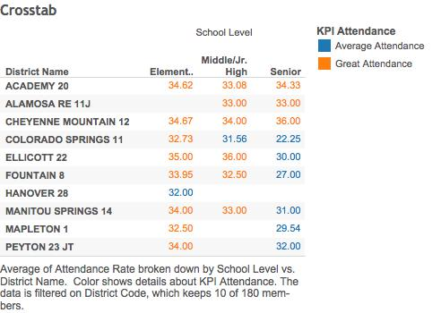

This crosstab shows the attendance rates of elementary, middle, high schools in 10 districts. We looked at a select number of districts to narrow down the information, so we filtered out schools that weren’t in districts 1-10. We noticed that most schools tended to range from lower 20s to the higher 30s. Thus, we set the our first KPI indicator of bad attendance to be any school with a average attendance rate of lower than 20. We set the average attendance rate to school’s whose average attendance rate fell between 20 and 32, and everything above 32 was considered great attendance. From the crosstab, we see that the majority of the schools in these 10 districts tend to have higher attendance rates, and none of these schools have bad attendance.

We then looked at the relationship between the average attendance rate and the reading and math growth rate in different types of educational plantypes.

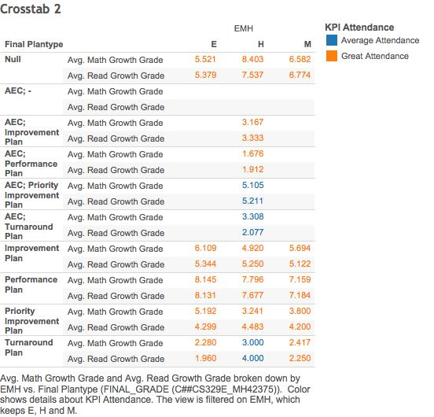

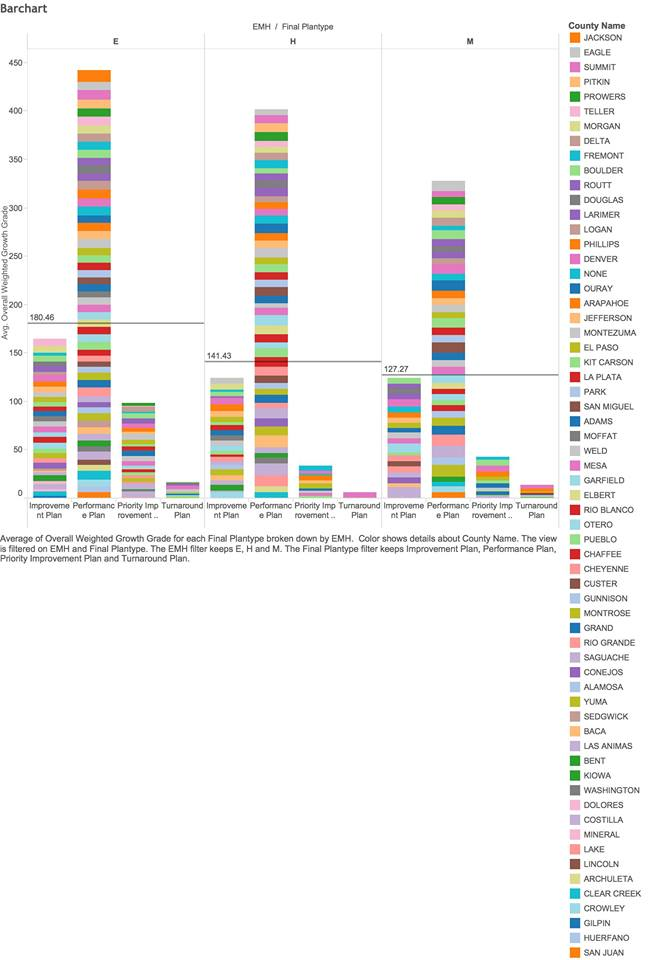

### **Shiny**

https://rarthur.shinyapps.io/DV_FinalProject

## **Conclusion**

Throughout this class, we have both learned a lot of of analytical skills as well as the technical skills that go behind creating a meaningful visualization. We now have experience filtering through good and bad datasets, blending them to make more meaningful connections, and displaying them in a user friendly way.